# 作業1

請依狀況更改上面的name,id及group（分別代表組員姓名，學號及組號），但請勿更改下面三行的設定。

姓名：陳柏銘, 蔡沛吟  
學號：410373092, 310356001  
組號：4

請直接在本檔案作答，存檔時也無需另存新檔名。交作業時，只由「組長」送出pull request給我。

作業除了讓同學檢視課堂所學程式外，有些題目只會給你未教過的函數建議（純為建議，你也可以不使用），你必需使用Help或網路查尋去了解函數的正確使用；搜詢正確程式函數使用的能力，也是程式設計的基本功。

如果是程式的答案，請設立如下的chunk區塊並在裡面作答

```r
#你的程式答案
```

如果是文字答案，請設立沒有{r}的chunk區塊並在裡面作答。

```
你的文字答案。
```

# 教育與薪資

一開始請執行

```r
rm(list=ls())
library(dplyr)
library(psych)
library(haven)
wage1 <- read_dta("http://fmwww.bc.edu/ec-p/data/wooldridge/wage1.dta")
wage1
```

| wage | educ | exper | tenure | nonwhite | female | married | numdep | smsa | northcen | south | west | construc | ndurman | trcommpu | trade | services | profserv | profocc | clerocc | servocc | lwage | expersq | tenursq |
| --- | --- | --- | --- | --- | --- | --- | --- | --- | --- | --- | --- | --- | --- | --- | --- | --- | --- | --- | --- | --- | --- | --- | --- |
| 3.10 | 11 | 2 | 0 | 0 | 1 | 0 | 2 | 1 | 0 | 0 | 1 | 0 | 0 | 0 | 0 | 0 | 0 | 0 | 0 | 0 | 1.1314020 | 4 | 0 |
| 3.24 | 12 | 22 | 2 | 0 | 1 | 1 | 3 | 1 | 0 | 0 | 1 | 0 | 0 | 0 | 0 | 1 | 0 | 0 | 0 | 1 | 1.1755730 | 484 | 4 |
| 3.00 | 11 | 2 | 0 | 0 | 0 | 0 | 2 | 0 | 0 | 0 | 1 | 0 | 0 | 0 | 1 | 0 | 0 | 0 | 0 | 0 | 1.0986120 | 4 | 0 |
| 6.00 | 8 | 44 | 28 | 0 | 0 | 1 | 0 | 1 | 0 | 0 | 1 | 0 | 0 | 0 | 0 | 0 | 0 | 0 | 1 | 0 | 1.7917590 | 1936 | 784 |
| 5.30 | 12 | 7 | 2 | 0 | 0 | 1 | 1 | 0 | 0 | 0 | 1 | 0 | 0 | 0 | 0 | 0 | 0 | 0 | 0 | 0 | 1.6677070 | 49 | 4 |
| 8.75 | 16 | 9 | 8 | 0 | 0 | 1 | 0 | 1 | 0 | 0 | 1 | 0 | 0 | 0 | 0 | 0 | 1 | 1 | 0 | 0 | 2.1690540 | 81 | 64 |
| 11.25 | 18 | 15 | 7 | 0 | 0 | 0 | 0 | 1 | 0 | 0 | 1 | 0 | 0 | 0 | 1 | 0 | 0 | 1 | 0 | 0 | 2.4203680 | 225 | 49 |
| 5.00 | 12 | 5 | 3 | 0 | 1 | 0 | 0 | 1 | 0 | 0 | 1 | 0 | 0 | 0 | 0 | 0 | 0 | 1 | 0 | 0 | 1.6094379 | 25 | 9 |
| 3.60 | 12 | 26 | 4 | 0 | 1 | 0 | 2 | 1 | 0 | 0 | 1 | 0 | 0 | 0 | 1 | 0 | 0 | 1 | 0 | 0 | 1.2809340 | 676 | 16 |
| 18.18 | 17 | 22 | 21 | 0 | 0 | 1 | 0 | 1 | 0 | 0 | 1 | 0 | 0 | 0 | 0 | 0 | 0 | 1 | 0 | 0 | 2.9003220 | 484 | 441 |

[output cut: 516 more lines]

1. 請依據此[連結](http://fmwww.bc.edu/ec-p/data/wooldridge/wage1.des)說明wage1資料的來源及變數代表意義。[其中potential experience指得是推估工作經驗年資]

```
1. wage1的資料來源是：Boston College
2. 本資料一共有24個變數。526筆觀測值
  1. wage                     average hourly earnings（平均時薪）
  2. educ                     years of education（受教育年限）
  3. exper                    years potential experience（推估工作經驗年資）
  4. tenure                   years with current employer（在目前工作待了幾年）
  5. nonwhite                 1，非白人；0，白人
  6. female                   1，女性；0，男性
  7. married                  1，已婚；0，未婚
  8. numdep                   孩子個數
  9. smsa                     =1 if live in SMSA (如果住在都會區)
 10. northcen                 =1 if live in north central U.S （是否住在美國北部）
 11. south                    =1 if live in southern region （是否住在美國南部）
 12. west                     =1 if live in western region（是否住在美西）
 13. construc                 =1 if work in construc. indus.（是否從事營建業）
 14. ndurman                  =1 if in nondur. manuf. indus.（是否從事製造業？)
 15. trcommpuut                 =1 if in trans, commun, pub （是否從事運輸業、通訊產業、公共事業（類政府部門）
 16. trade                    =1 if in wholesale or retail（是否從事批發或零售等服務業）
 17. services                 =1 if in services indus.（是否從事服務業）
 18. profserv                 =1 if in prof. serv. indus.（是否從事專業服務業）（也許是會計師、顧問等等）
 19. profocc                  =1 if in profess. occupation（是否擔任專業職）
 20. clerocc                  =1 if in clerical occupation（是否擔任行政職）
 21. servocc                  =1 if in service occupation（是否擔任服務職）
 22. lwage                    log(wage)
 23. expersq                  exper^2
 24. tenursq                  tenure^2
```

我們想要問：“教育年限增加一年對勞動薪資的影響有多少？”

2. 請使用`psych::pairs.panels()`來描述教育年限(educ)與勞動薪資(wage)間的特質。在兩者的相關度上，有沒有那個變數取對數(log)會比較好？為什麼？

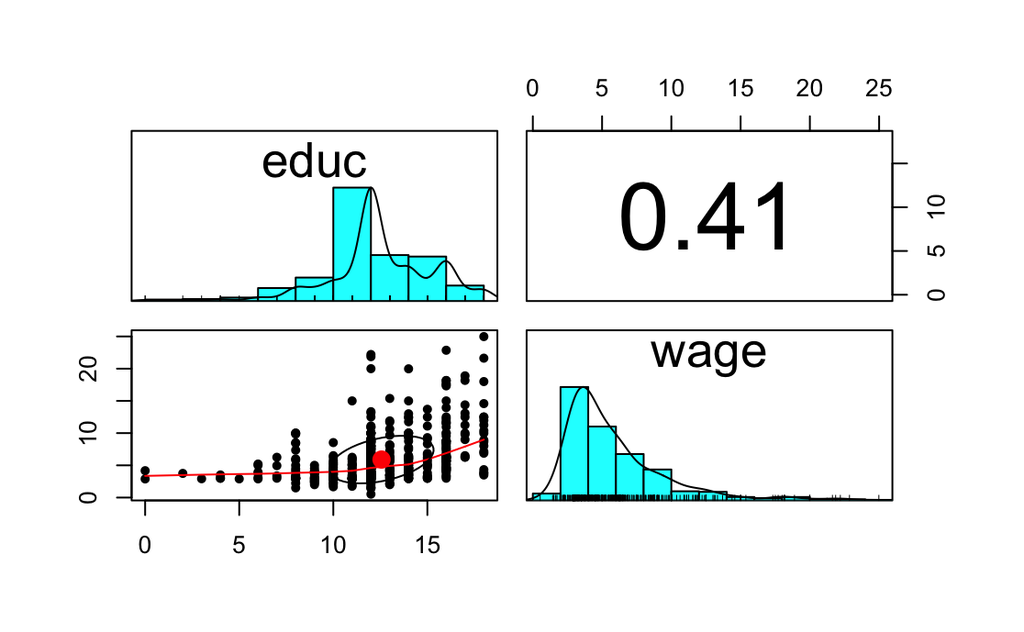

```r
wage1 %>% select(educ, wage) %>% psych::pairs.panels()
```

```r
#由目前的圖來看，對wage取log叫好，因為可以使其更接近常態分配。
```

若嘗試對wage取log之後呢…(直接用`lwage`變數)

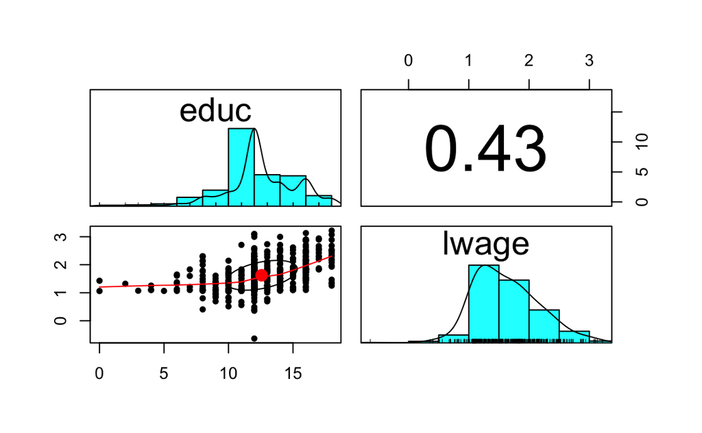

```r
wage1 %>% select(educ, lwage) %>% psych::pairs.panels()
```

3. 請使用OLS估計以下的迴歸模型：
   $$log(wage)=\beta_0+\beta_1 educ+\epsilon$$

```r
wage1 %>%
  lm(formula = lwage~educ) #這邊因為formula有設定好。那data就會放到第二個參數，剛好是data，也就可以跑了。
```

```
Call:
lm(formula = lwage ~ educ, data = .)

Coefficients:
(Intercept)         educ
    0.58377      0.08274
```

```r
#迴歸式：lwage = 0.58377 + 0.08274educ + epislon
```

4. 從資料裡選出兩個可能造成$\beta_1$OLS估計值帶有選擇性偏誤的變數，請說明理由並加以適當敍述統計量佐證。

```
註：針對類別資料的0/1，不是數值資料，而是類別資料的表達。那取log是沒有意義的。資料型態的問題也需要特別留意。

我會挑幾個變數，分別是：nonwhite、female、numdep
目前受教育這個treatment的立足點，就是沒有受教育。
是否接受過教育從當下往前推的角度來看，有許多因素會影響一個人是否能夠接受到教育。
Seletion bias是指個體立足點會影響其是否接受試驗與否。
其中，nonwhite是指是否為白人，female是指其為男性或女性。
若上述兩變數與lwage的相關係數偏高，我們有理由懷疑其實我們測到的並不是教育年限對薪資的影響，
反而也包含了立足點不同的雜訊。畢竟（白人）、（男性）、（小孩越少將較有能力把重心放在自己去接受更多教育），是比較容易接受到教育的(也就是beta_0不見得是一樣的）。
```

```
答案更正方向：在探究selection bias，需要去考量他和educ（X 主要解釋變數）和lwage（Y）的相關係數。不然就算他跟educ有關，跟lwage無關，那你加入他又有什麼用。這是觀念問題，操作上也是兩個相關係數都要表達。
```

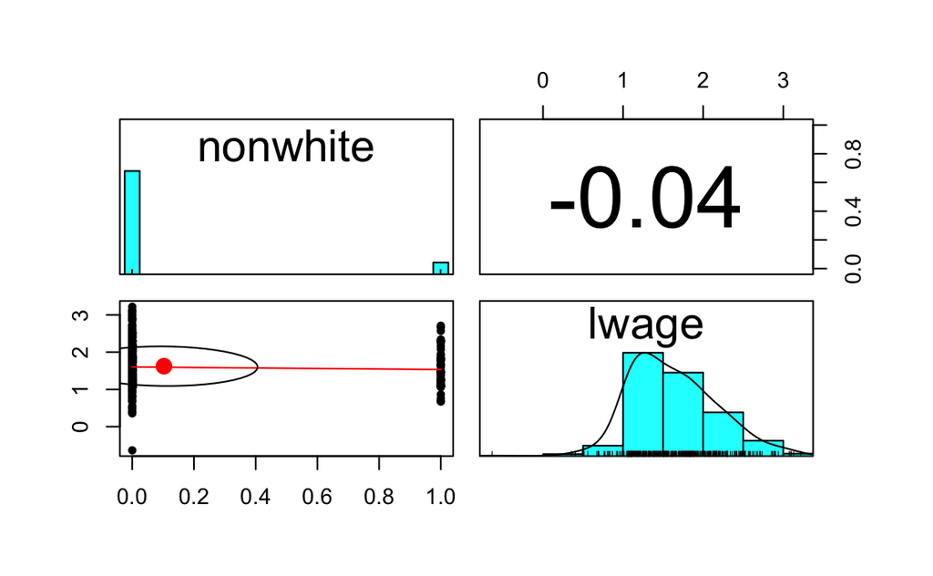

```r
wage1 %>% select(nonwhite, lwage) %>% psych::pairs.panels() #-0.04
```

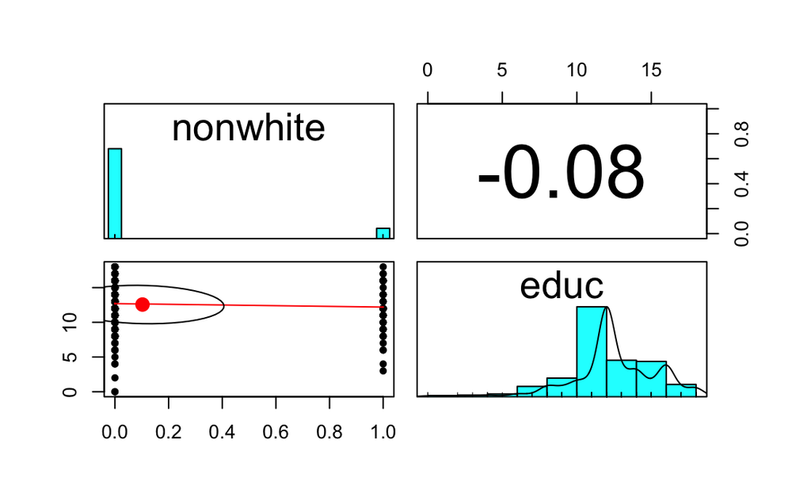

```r
wage1 %>% select(nonwhite, educ) %>% psych::pairs.panels() #-0.08
```

```r
#其實你可以知道的是基本上（是不是白人）不會照成選擇偏誤。因為nonwhite對於educ受教育的解釋能力（相關係數，線性關係的能度）很低。對被解釋變數的lwage也是一樣的。
```

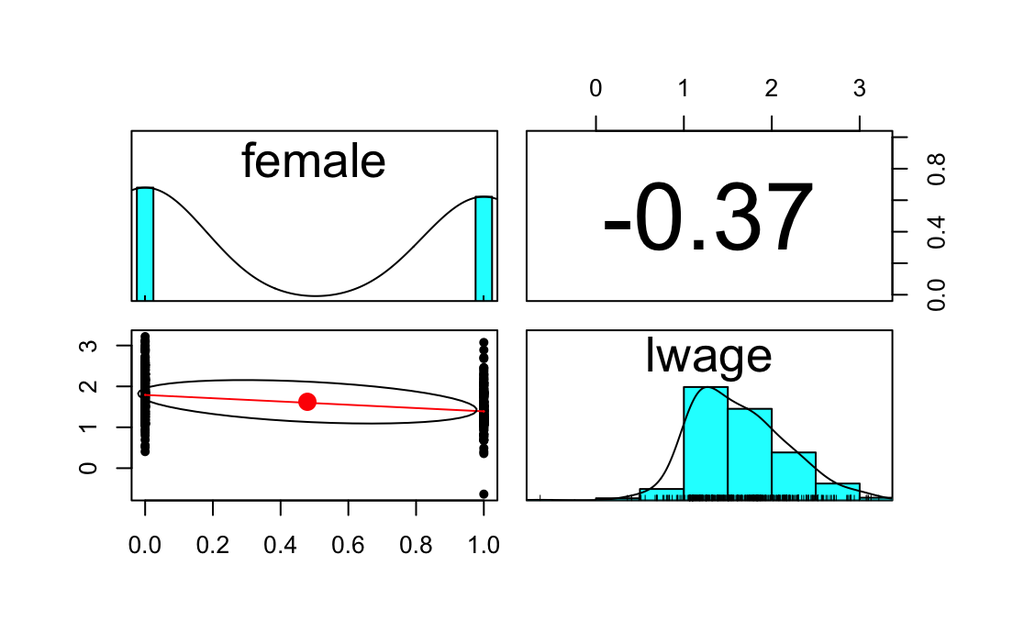

```r
wage1 %>% select(female, lwage) %>% psych::pairs.panels() #-0.37
```

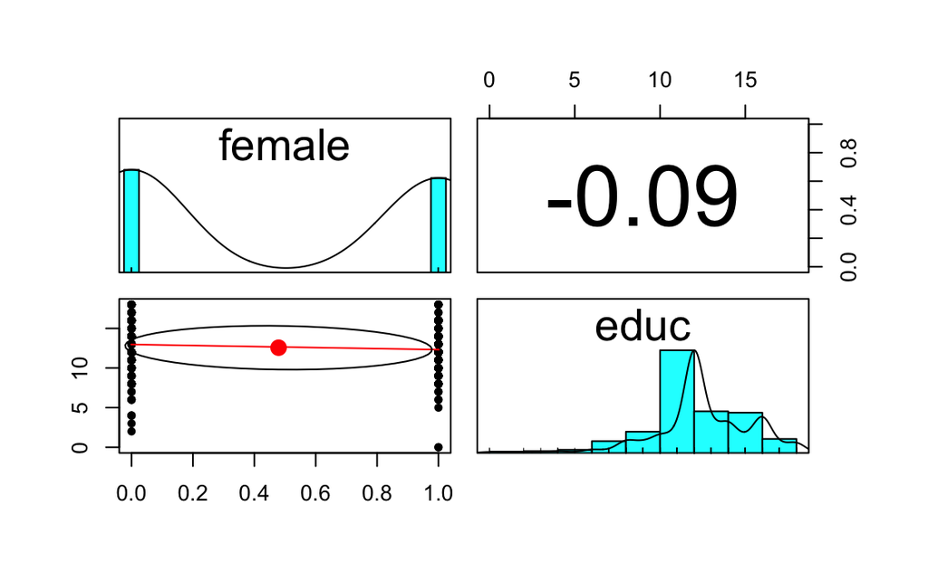

```r
wage1 %>% select(female, educ) %>% psych::pairs.panels() #-0.09
```

```r
#由這邊可以看到性別和受教育的相關程度偏低，但是性別確實會影響工資。造成選擇偏誤的故事背後的數據力可能還不夠充分。因為看起來，是否為女性的立足點，不至於影響他是否接受treatment
#可以參考學長的做法。（下個chunk)
```

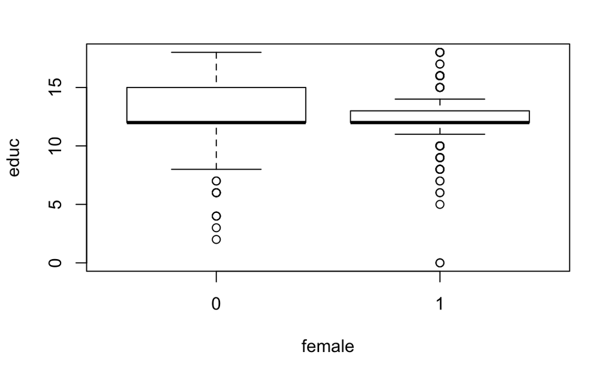

```r
boxplot(wage1$educ ~ wage1$female, xlab="female", ylab="educ")
```

```r
wage1 %>% group_by(female) %>%
  summarise(mean(educ,na.rm=T),sd(educ,na.rm=T))
```

| female | mean(educ, na.rm = T) | sd(educ, na.rm = T) |
| --- | --- | --- |
| 0 | 12.78832 | 3.002882 |
| 1 | 12.31746 | 2.472642 |

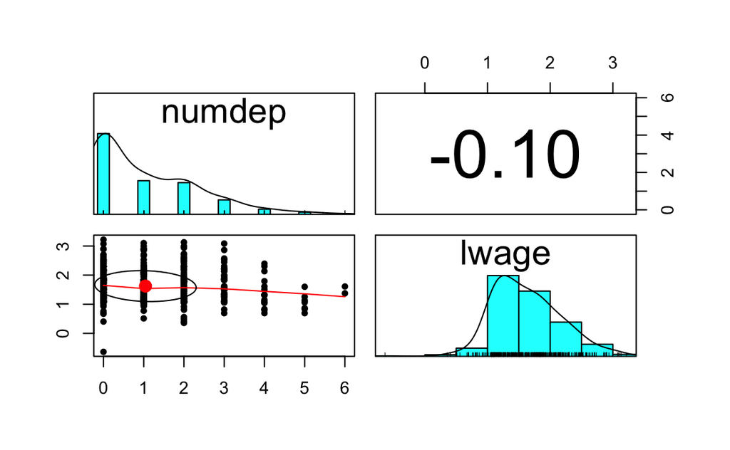

```r
wage1 %>% select(numdep, lwage) %>% psych::pairs.panels() #-0.10
```

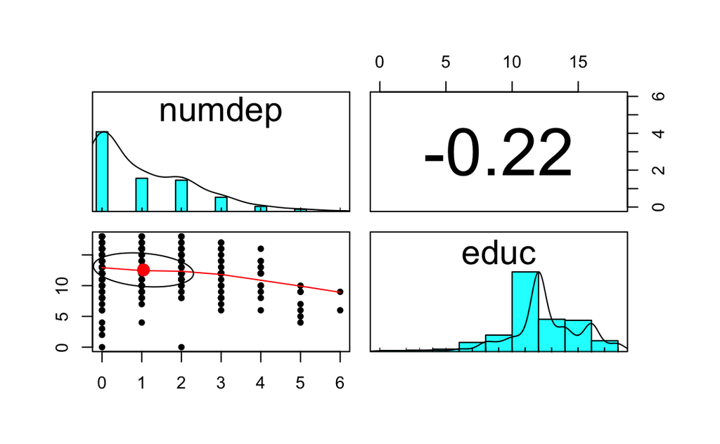

```r
wage1 %>% select(numdep, educ) %>% psych::pairs.panels() #-0.22
```

```r
#孩子的個數也還好。他確實會造成立足點是否接受treatment的不同（孩子越多真的越沒空進修。但是他不見得會同時影響工資。
```

5. 延續上題，請完成對應複迴歸模型的估計。

```r
wage1 %>% lm(lwage~educ+female, data = .)
```

```
Call:
lm(formula = lwage ~ educ + female, data = .)

Coefficients:
(Intercept)         educ       female
     0.8263       0.0772      -0.3609
```

6. 大致說來，教育年限12年表示高中畢業，大學畢業會有16年的教育，請問介於12年以上-16年以下的教育年限代表什麼？

```
教育年數介於12年以上，16年以下，代表的是他僅有高中學歷，或者大學肄業（休學）就進入職場。
```

7. 取出教育年限介於12-16年（含上下限）的資料，分別計算以下三群教育年限勞動者的平均薪資：12年，13-15年，16年。 [hint: dplyr::filter(), dplyr::group_by(), dplyr::summarise(), cut()]

```r
wage1 %>%
  filter(educ >= 12 & educ <= 16) %>%
  group_by(cut(educ, c(11, 12, 15, 16))) %>%
  summarise(avgwage = mean(wage), n=n()) -> wageforUniTreatment #n=n()是可以計算樣本數，就是求平均的那個，分母的n
names(wageforUniTreatment)[1] <- "EducInterval"
wageforUniTreatment
```

| EducInterval | avgwage | n |
| --- | --- | --- |
| (11,12] | 5.371364 | 198 |
| (12,15] | 6.030000 | 113 |
| (15,16] | 8.041618 | 68 |

8. 在下一部份的文章閱讀練習裡，文章提到:

> In a comparison of the earnings of people with degrees and people without them, those who start university but do not finish are lumped in with those who never started, even though they, too, will have paid fees and missed out on earnings. Their numbers are considerable.

在問題7中我們計算了三群人的平均薪資。請問若要避免文章所描述的問題，你會如何計算一位高中生若選擇上大學他會得到的預期薪資好處。[只使用問題7的數字及三群人人數]

```r
### 答案訂正方向：
wageforUniTreatment %>% filter(EducInterval %in% c("(12,15]","(15,16]")) %>%
  summarise(weightavgwage = weighted.mean(avgwage, w=c(113, 68)))
```

| weightavgwage |
| --- |
| 6.785746 |

```r
#%in% operator是指：是否包含...並且回傳T F
#所以這邊就是是否包含"字串內容"，會用字串主要原因是因為類別變數的關係。
#若不用weighted.mean的方式，就變得要
6.030000*(113/(113+68))+ 8.041618*(68/(113+68)) - 5.371364
```

```
[1] 1.414382
```

# 文章閱讀

[Going to university is more important than ever for young people. But the financial returns are falling.](https://www.economist.com/news/international/21736151-financial-returns-are-falling-going-university-more-important-ever)

文章中有不少效應評估問句，及造成其無法直接進行簡單迴歸估計的選擇性偏誤原因，請將所有這樣的段落貼過來、寫下它的效應評估問句及造成選擇性偏誤的原因（文章中所提的，非自我發揮）。例如：

**註：看馬丁怎麼補充，普遍寫得很爛…**

``` Seletion bias是指個體立足點會影響其是否接受試驗與否。

1. Policymakers regard it as obvious that sending more young people to university will boost economic growth and social mobility. … But comparisons between countries provide little evidence of these links. Richer countries have more graduates, but that could be because there is more money to spare, and less urgency to start earning.

效應評估問句：越多人上大學該國經濟表現越好？

造成選擇性偏誤原因：「時間多錢多多」造成「越多人上大學」，「時間多錢多多」是「富有國家」常見現象，所以單純比較上大學比例高和低的國家，有可能只是在比誰的「時間多、錢多」。（這類的選擇性偏誤也稱為內生性偏誤。）

2. The World Bank has produced estimates of this return for 139 economies. It varies from place to place, but is substantial everywhere. The Economist’s analysis of the data finds that returns are linked to the share of people with degrees, and the range of earnings. Returns in Britain and Germany are similar to those in America. In sub-Saharan Africa, where degrees are scarce and the least-educated workers earn little, they are around 21% a year. In Scandinavia, where wages are less unequal and two-fifths of adults have degrees, they are around 9%.

效應評估問句：該地區越多人擁有大學學歷，學歷報酬越低？ 造成選擇性偏誤原因： 看起來，立足點是「該地區有較低人口比例有高學歷」，主要解釋變量是：是否為高人口比例有大學學歷的地區。其coefficient應該<0。這可能忽略了所屬地區的產業環境需要高學歷族群的多寡，理由是因為若產業環境不佳，人才供給過剩，越多人擁有大學學歷，那麼必定學歷貶值。但是若產業環境蓬勃發展，需要更多高端人才的比例提高，有可能越越多大學學歷者投入勞動市場，創造產值越多，市場餅越大，吸引更多人才進入，最後人人有分紅。 單純迴歸分析，有可能只是在比誰的產業環境較佳，較有發展潛力。

3. In a new book, “The Case Against Education”, Bryan Caplan of George Mason University argues that the low graduation rates of marginal students, and the fact that, for a given level of qualification, cleverer people tend to earn more, mean that the return on a four-year degree in America ranges from 6.5% for excellent students to just 1% for the weakest ones.

效應評估問句：越聰明的人，其上大學的學歷報酬越高？ 造成選擇性偏誤原因：若單純只比較聰明與不聰明對學歷報酬的影響，是需要留意通常聰明人學習能力較好，成績表現也較優異，所以進入到好大學的機會比較高，所以最後只有可能在比較進入好學校對於學歷報酬的影響（也就是表面上立足點是不聰明的人，treatment是（是否為聰明人），但是實際上會測到的是立足點是進到普通大學，treatment是進入到好大學。

4. In a study published in 2014 Seth Zimmerman of the University of Chicago compared the earnings of school-leavers in Florida whose grades were close to the minimum for admission to a good state university. Those just above the cut-off were much more likely than those just below to start courses in good institutions. They graduated at a rate similar to that of the broader student population. They went on to earn considerably more than those just below the cut-off, and their return on investment was substantial.

效應評估問句：榜上有名讀到好大學的人，其學歷報酬較高？ 造成選擇性偏誤原因：讀到好大學的同學和普通大學的同學，比較他們日後賺錢的多寡，需要留意好的私立學校（以美國為例）學費並不便宜，若單純只比較讀到好大學的同學和爛大學，有可能只是在比誰家庭環境較理想，有的環境較多，較有能力上好的私立大學。